# Project 1

Qianli Zhu UNI2310

January 27, 2018

As we know, the Democratic party and the Republican party are two main parties of the United States, and each party has its own principle. The Democratic party advocates freedom and pays more attention to people’s welfare and multi-culture. The Republican party pursues conservative, and mainly focuses on building up an unrestricted market for business. So, as a president candidates of each party, they must follow the idea of their own party.

So, we could consider that:

*What the political difference would be between two parties, from the perspective of the presidents and president candidates’ speech?*

### **INTRODUCTION:**

In this project, we are going to mainly demonstrate the statement if there exists any political difference between two parties, from the perspective of each party’ presidents and president candidates’ speeches. In other words, the inaugural speech each party’s president made would follow the principal his or her own party or would be determined by current situation of country.

The analysis has following three parts: a. General Idea of structure of speech b. Sentimental analysis c. Topic Modeling & Analysis

### **ANALYTICAL PARTS:**

##### a. General idea of structure of speech

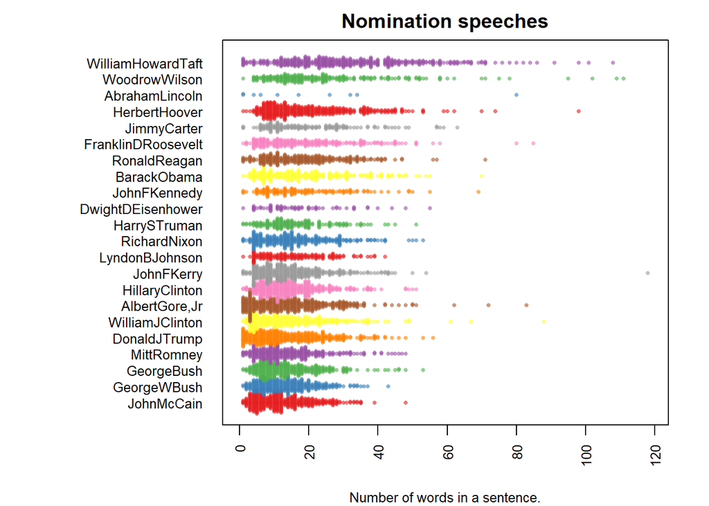

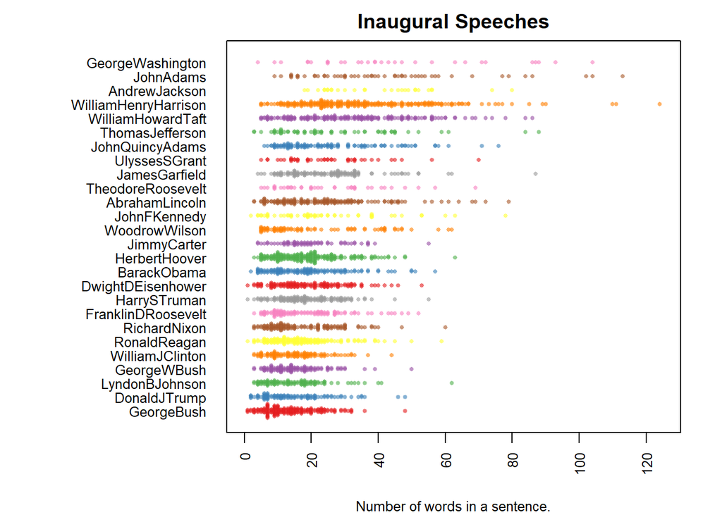

##### b. Sentimental Analysis

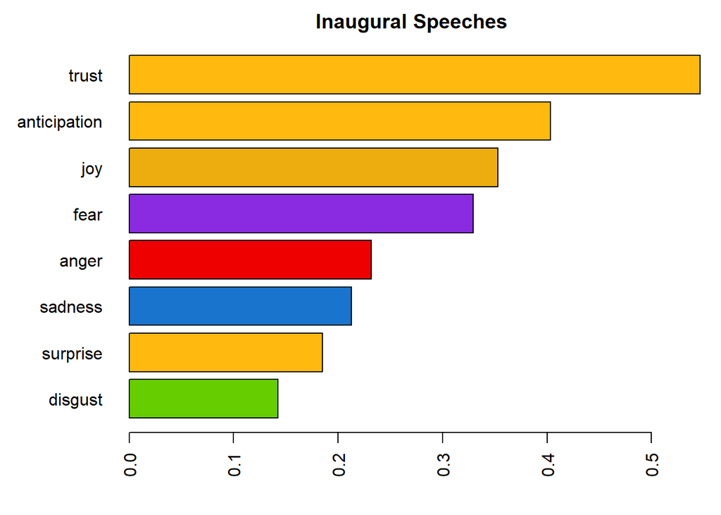

First of all, the bar plot above shows the overall emotion of inaugural speeches consists, and we can find out the trust has a heavy weight for speeches. It really makes sense, since each elected presidential candidate need to be confidence to make such speech, in order to make audience have faith to their ability and political strategies for future.

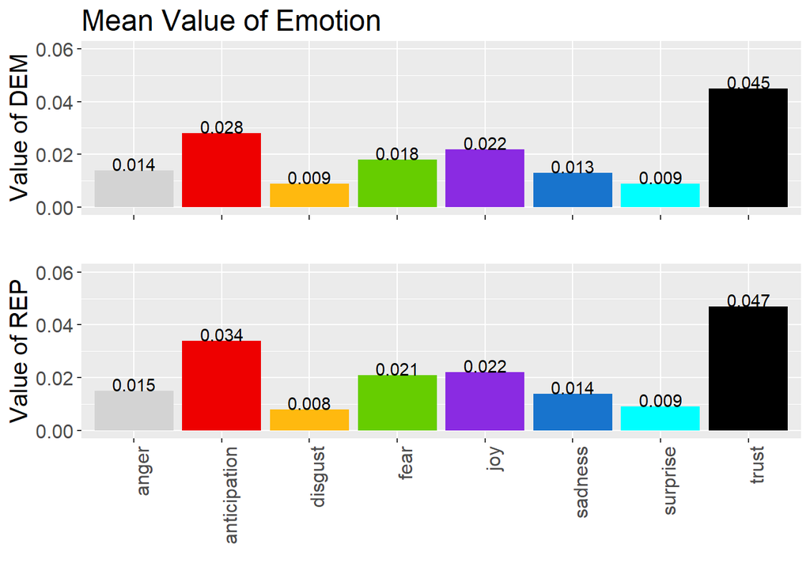

Next, we find out the mean value of all different kinds of emotion for each party’s president, which calculated by the emotion data of the democratic and republican presidents’ inaugural speech. The result shows that the strength of emotion of the Republican president is stronger than of the democratic president, especially the value of anticipation. In other words, the higher value of anger, anticipation, and trust indicates that republican presidents are more aggressive when they make inaugural speech. It also indicates that the Democratic presidents is ambition about their future development as a president of the United Sates.

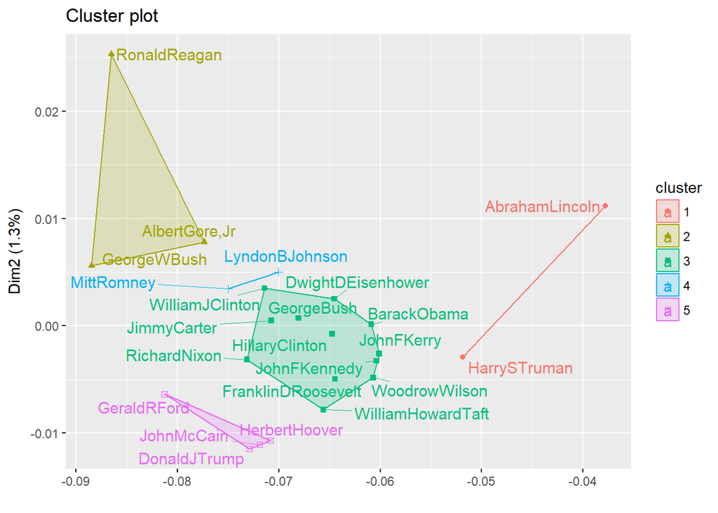

##### c.Topic Modeling&Analysis

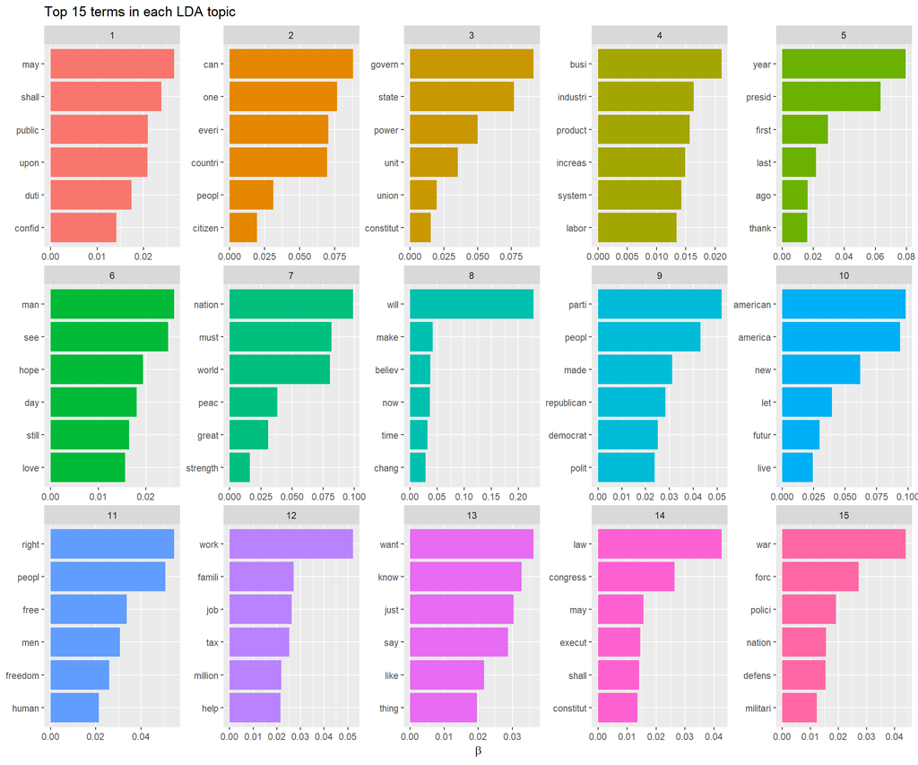

First of all, we use LDA to make topic modeling, and select 6 highest frequency words of 15 topics, and it helps us to figure out what’s each topic related to, and we could get an overview of the popular topics of inaugural speeches. According to our term list, we could conclude following list for 15 topics: “Economy”, “Responsibility”, “Defense”, “Belief”, “Business”, “Patriotism”, “Election”, “Government”, “Reform”, “American”, “Employment”, “Freedom”, “World”, “Legislation”, and “War”.

Moreover, in order to have better idea about each party’s most favor topic in their presidents’ inaugural speech, we make following to plot:

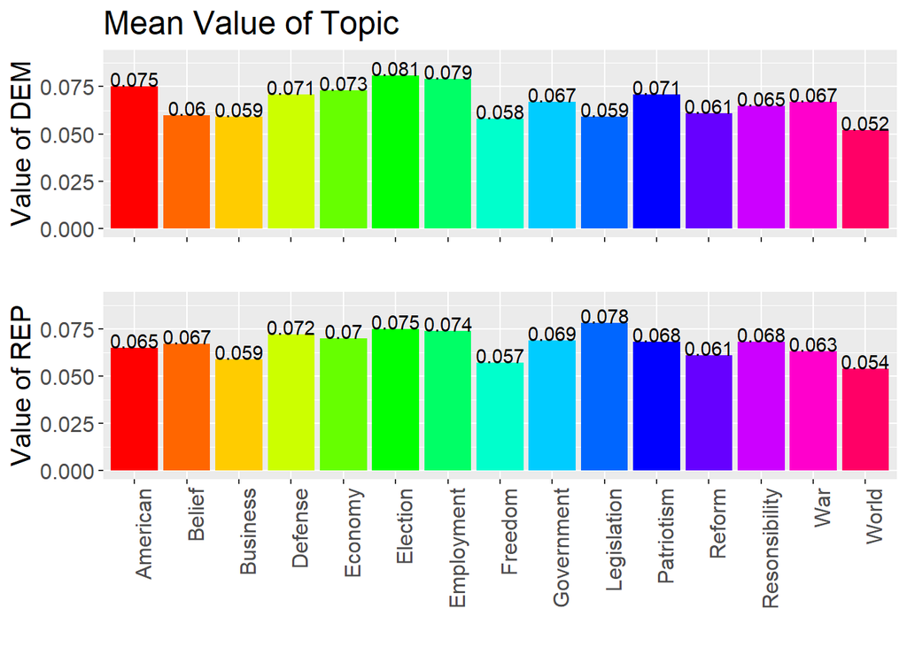

The plot shows that, even though, the value of each topic is quite close between each party, and we could still find out that each party has their own emphasis in each topic. One hand, democratic presidents have more emphasis in “Employment”, “Economy” and “American”. On the other hand, republican presidents mainly focus on “Responsibility”, “Government”, and “World”. The surprising thing is that, as an aggressive party, the value of “War” of republican presidents is lower than the value of democratic presidents.

Taking more closely about what each party’s president said, we also make word cloud plot for 4 well-known presidents, each 2 of them from different parties, to find out the key words of their inaugural speeches.

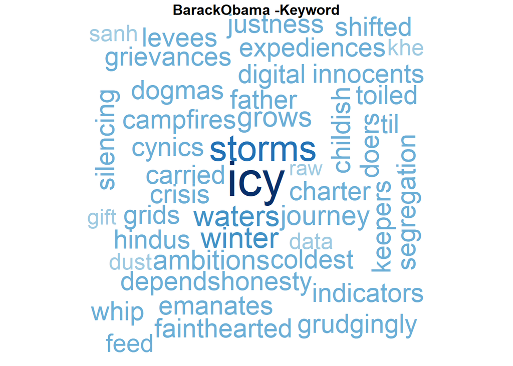

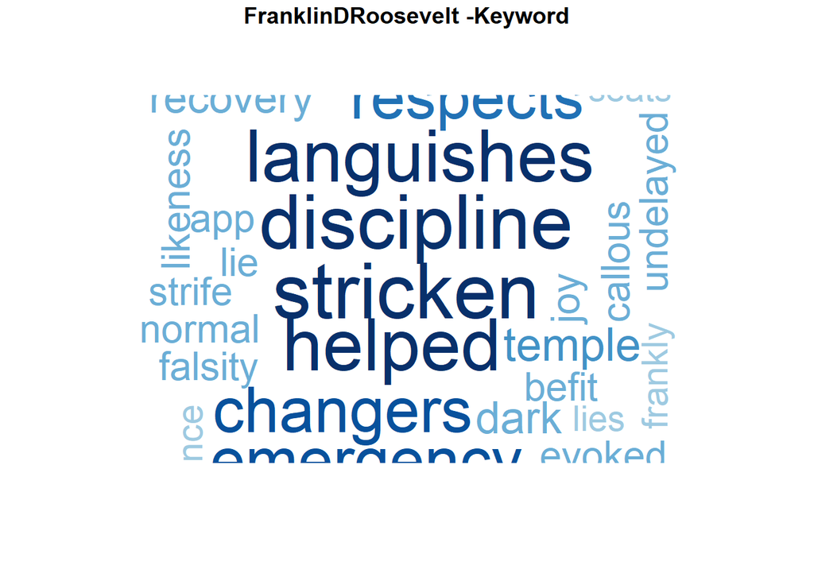

Looking at the cloud plot of Barack Obama, the word “icy” has the highest frequncy, and second noticable term is “storm”. Other remarkable words also have “crisis”, “ambitions”, and “doers”, etc. It could imply that Obama is trying to descript the severity of financial crsis at that time, which he used the metaphor of “winter” and “storm”. For Franklin D. Roosevelt, the keys words, “helped”, “emergency”, and “changers”, could show that he is trying to devote himself to change current situation of the United States. Both elected presidents were facing an unfavorable economic situation of country at that time, but the language between their speeches is still quite different. The keywords of Obama’s speech is more likely to depict how bad the situation is now, but the keywords of Roosevelt’s is trying to offer help.

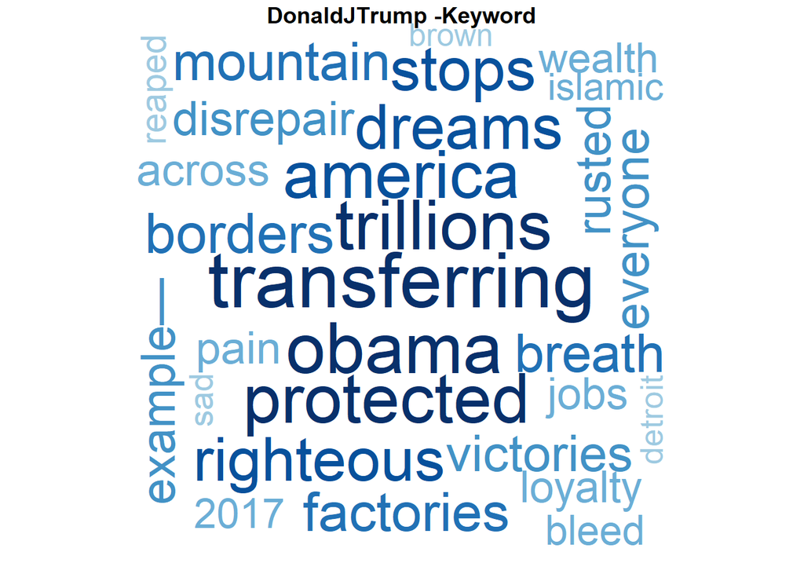

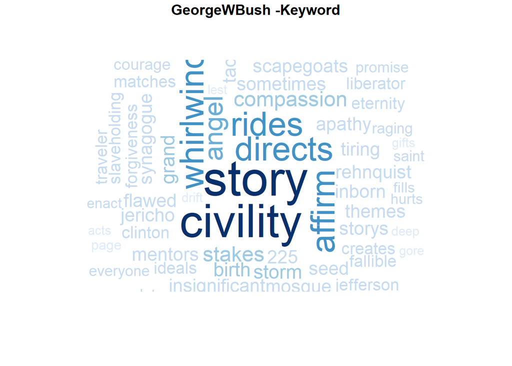

For Donald Trump and George W. Bush, two aggressive presidents of the United States, the key words have totally different emphasis. Trump focuses on the topic of employment and predecessor. However, Bush more emphasizes on the “civility” and “story”, which hardly to predict his speech context without reading the full text.

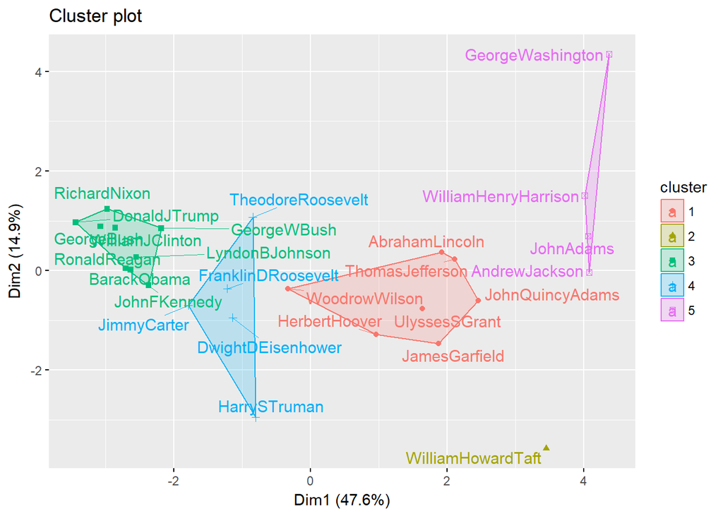

At last, in the topic clustering plot, we could find out that each area consists presidents, which elected at approximately same era, so, it indicates that the inaugural speech each president made would stick with current problem the country has. Further, combining the results of word cloud plot, we could conclude that although every president represents his own party’s principal, and his political strategies will only focus on how to solve the problem of country.

### **SUMMARY:**

At last, we could answer our question we came up with at the beginning that president’s inguaral speech is representing people, rather than his or her party’s principal.